# Preliminary data report of the Québec Biodiversity Monitoring Network in Nunavik

Joëlle Spooner

2025-04-09

[figure not shown]

[figure not shown]

[figure not shown]

# The Québec Biodiversity Monitoring Network

The results presented below are preliminary findings from the Québec Biodiversity Monitoring Network. This long-term initiative aims to track the impacts of climate change on biodiversity by monitoring key species and environmental indicators across the province. As the project is still in its early years, it is too soon to draw conclusions about the effects of climate change. However, the monitoring efforts already provide valuable insight into northern biodiversity and have even led to the discovery of new species.

Several Nunavik communities are actively involved in this work, alongside monitoring efforts in Nunavik Parks and protected areas. The preliminary results showcased here highlight some data collected over the past few years, including bird populations, lake fish diversity, and spider communities. This collaborative effort would not be possible without the contributions of the Uumajuit Wardens, Nunavik Parks, the Protected Areas Section of Kativik Regional Government (KRG), the Nunavik Research Center, the Centre d’études nordiques (CEN), the Nunavik Sentinels and Anguvigait.

The collected data can be downloaded on the Biodiversité Québec platform (biodiversite-quebec.ca/en/inventaires) when you log in. See the email for the log in and data download procedures.

# Birds

Birds are monitored using acoustic recorders installed in wetlands, forests, and tundra across several Nunavik communities and other regions of the province. These devices capture bird songs from spring through autumn. Later, experts listen to the recordings and identify the bird species based on their vocalizations.

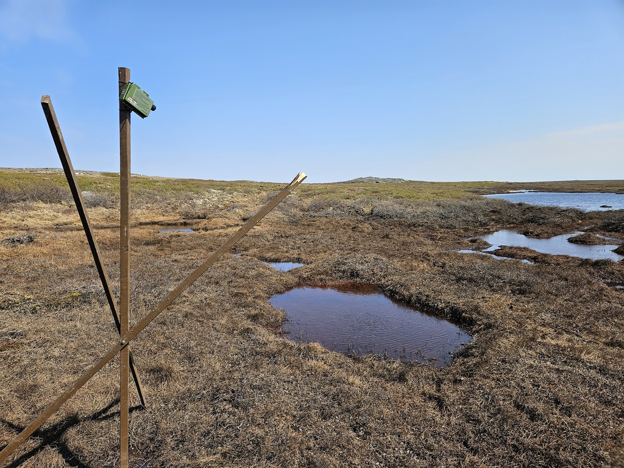

Acoustic device installed in a wetland in Inukjuak in 2024

© Caroline Dubé, MELCCFP.

## Most frequently detected bird species in Nunavik

The most commonly detected species in Nunavik is the White-crowned Sparrow. In fact, this bird was heard in nearly half of all the recordings we analyzed! You’ve likely seen this species before, often hopping along the ground or in bushes below waist height. It’s easily recognizable by the bold black-and-white stripes on its head. Other species might be very common in Nunavik, but we may detect them less often using acoustic monitoring. Low detection doesn’t necessarily mean a species is rare in Nunavik. Some species may be less vocal or simply not be present in the habitats we monitor, such as shoreline environments, which are currently not included in our surveys.

You’ll also notice that our most recent data only goes up to 2021. That’s because it takes a lot of time and effort for experts to carefully listen to the recordings and identify the birds. On average, it takes about two years before the data becomes available. Rest assured, we collect acoustic data every year, and our team is hard at work processing and analyzing it as quickly as possible!

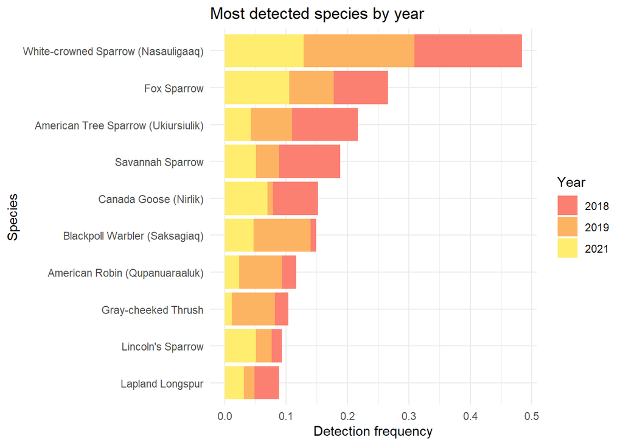

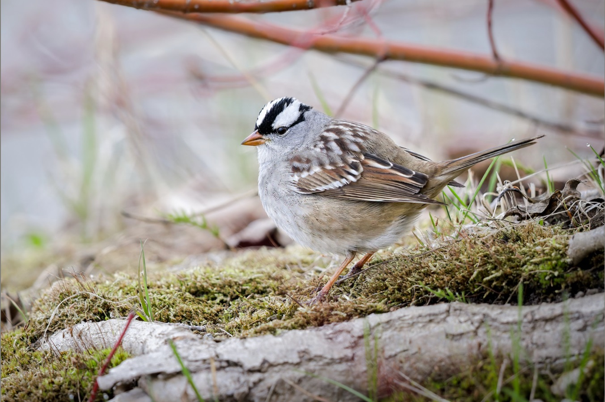

White-crowned Sparrow (Nasauligaaq)

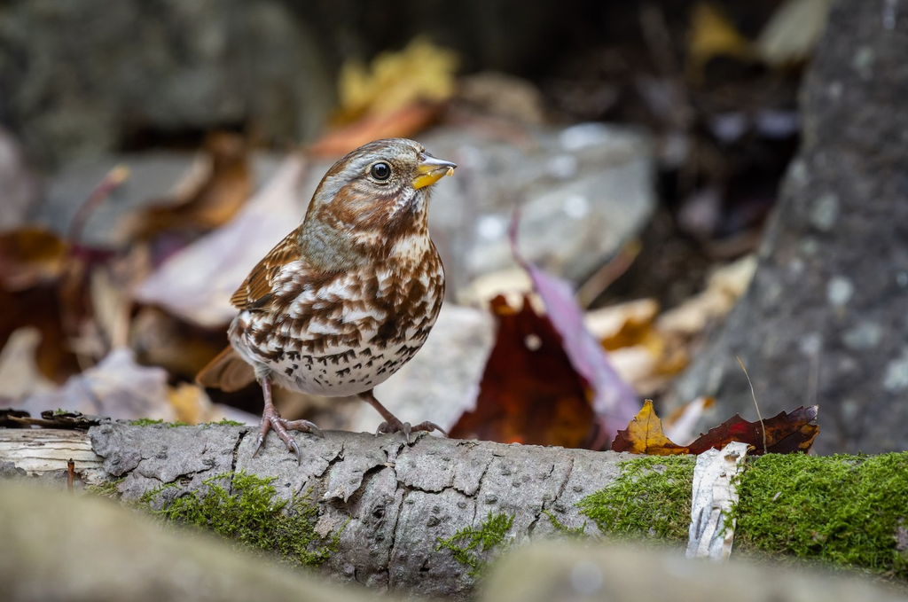

Fox Sparrow

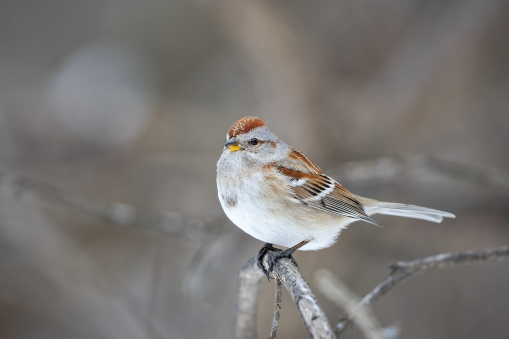

American Tree Sparrow (Ukiursiulik)

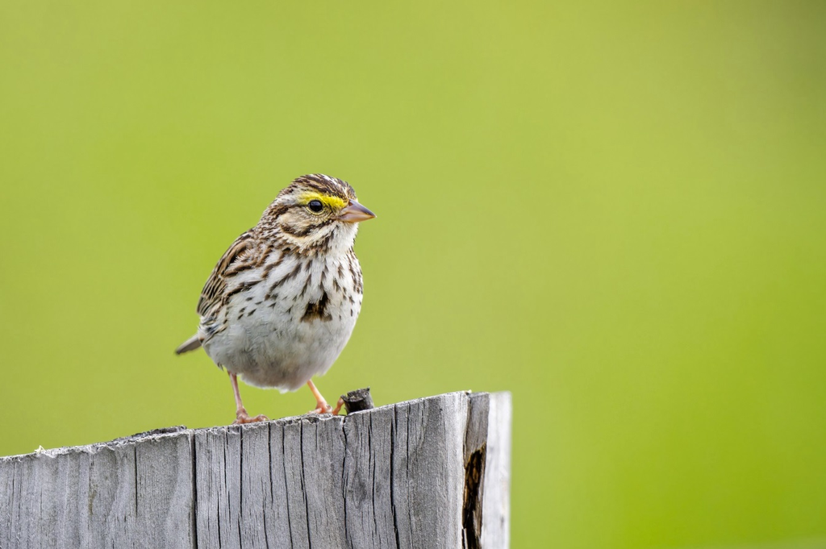

Savannah Sparrow

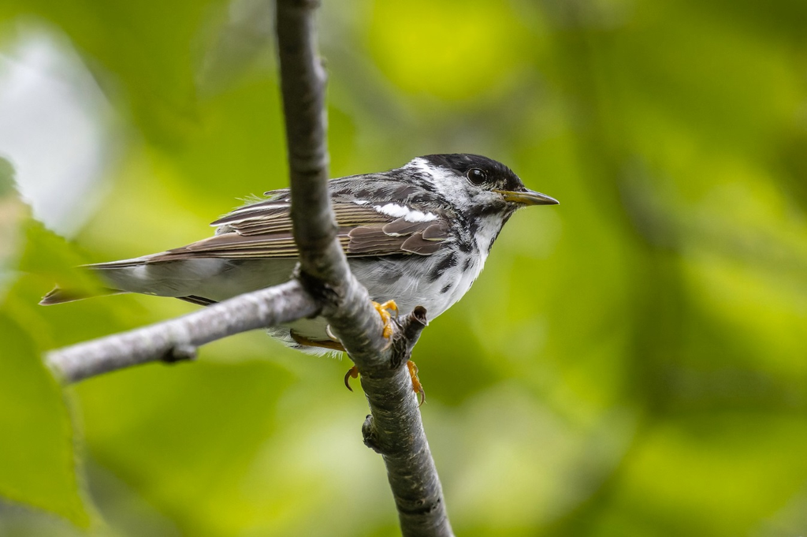

Blackpoll Warbler (Saksagiaq)

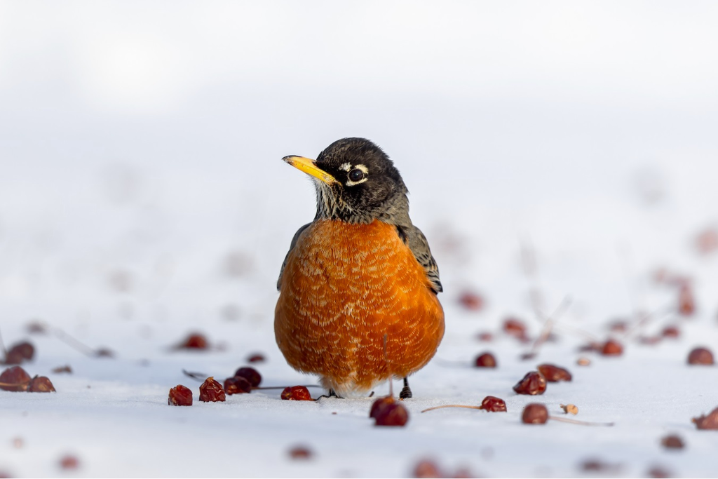

American Robin (Qupanuaraaluk)

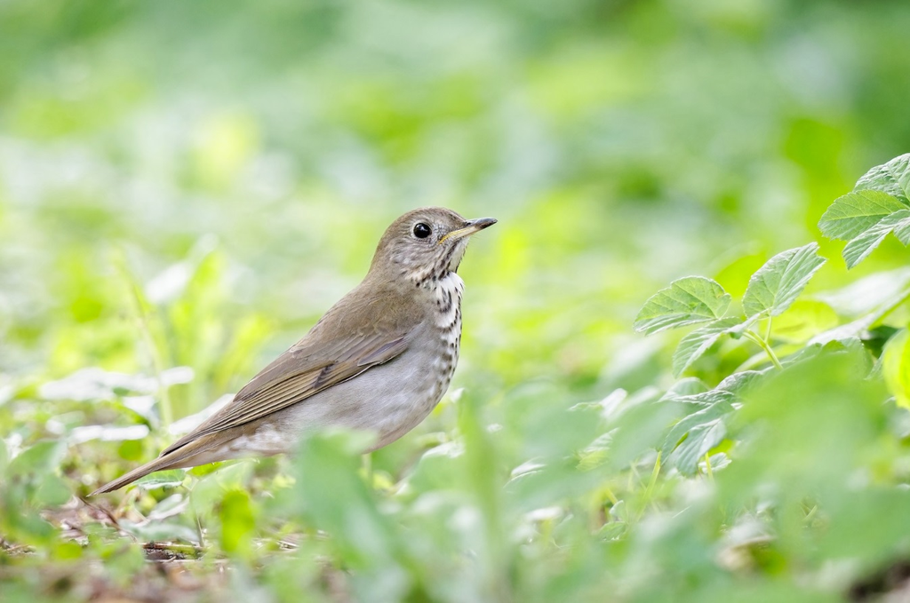

Gray-cheeked Thrush

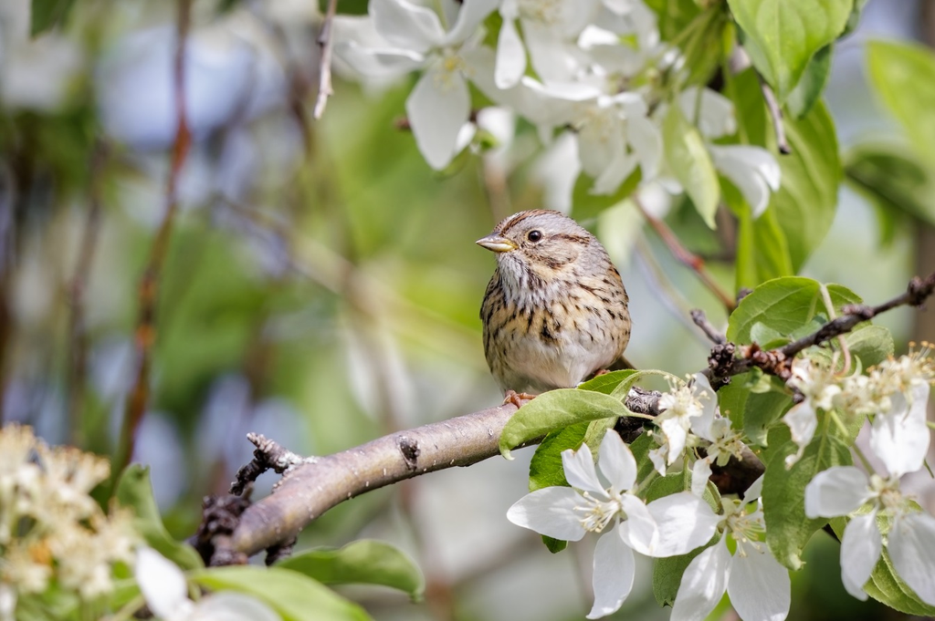

Lincoln Sparrow

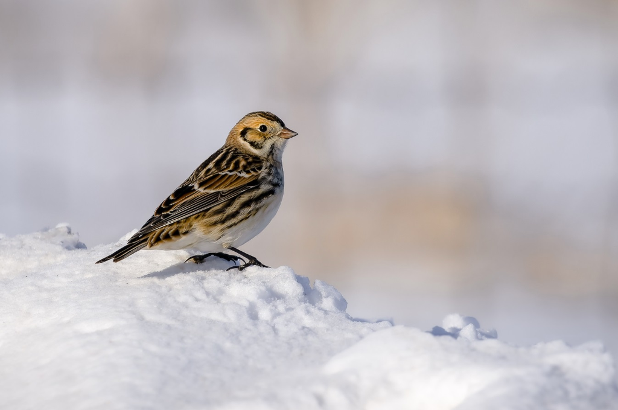

Lapland Longspur

All pictures were taken by © Frédéric Lelièvre, MELCCFP.

# Lake Fish

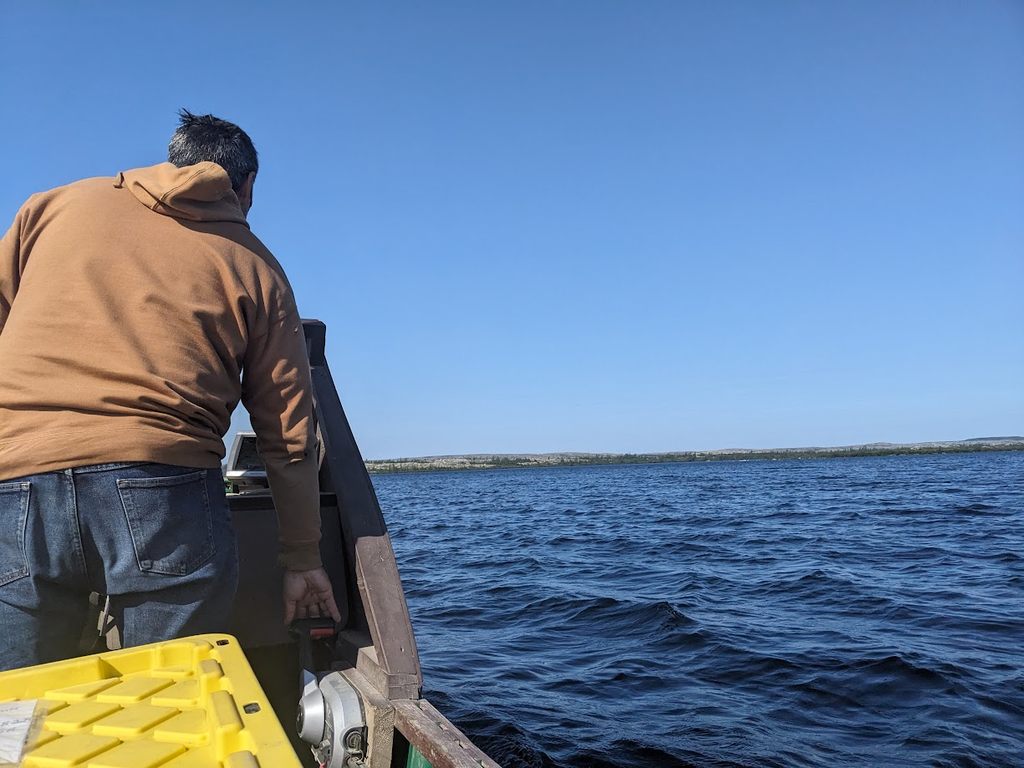

Lake monitoring in Tasirlaq (Kuujjuaq) in 2024 with Alec Ningiuruvik, Francis Lessard and Joëlle Spooner

© Joëlle Spooner, MELCCFP.

## Detected species by environmental DNA in two Nunavik lakes

eDNA samples were collected from Mivviviniq (Kangiqsualujjuaq) and Tasirlaq (Kuujjuaq) during the summer of 2023 with the support of Uumajuit Wardens Elijah Etok and Alec Ningiuruvik. Fish DNA in water samples comes from sources like scales, eggs, secretions, and feces. In Mivviviniq and Tasirlaq, DNA sequences from a variety of species were detected in the samples collected. Environmental DNA (eDNA) is a powerful tool to gain insights on biodiversity. However, eDNA sampling is sensitive to contamination from other DNA sources, including people handling the samples or other organisms present in the ecosystem. As a result, traces of human, caribou, or even pork DNA (perhaps from someone’s lunch) can sometimes be found! Contamination with fish DNA can also occur if, for example, someone uses fish as bait or if DNA from a different lake is carried downstream by a tributary. To minimize contamination, we thoroughly disinfect all equipment, boats, and clothing before sampling. Even with strict precautions, some contamination can still happen.

To ensure reliable results, we apply a decision tree that evaluates the amount of DNA sequences detected for each species. Confirming a species’ presence in a lake requires meeting several criteria, such as previous detection in the same lake or a sufficient quantity of DNA sequences in the samples. Despite the challenges, eDNA remains a powerful and effective tool for creating a snapshot of fish species present in a lake and monitoring how species compositions change over time.

Fish DNA Sequences Detection in Mivviviniq and Tasirlaq

| Lake | Latin Name | English Name | Inuktitut Name | Amount of DNA Sequences |
| --- | --- | --- | --- | --- |
| Mivviviniq | *Salvelinus namaycush* | Lake trout | Isiuralittaaq | 14319 |
| Mivviviniq | *Salvelinus fontinalis* | Brook trout | Aanak | 80090 |
| Mivviviniq | *Salvelinus alpinus* | Arctic char | Iqaluppik | 103321 |
| Tasirlaq | *Catostomus catostomus* | Red sucker | Milugiak | 25028 |
| Tasirlaq | *Coregonus artedii* | Arctic/Lake cisco | Kavisiliaruk | 33094 |
| Tasirlaq | *Coregonus clupeaformis* | Whitefish | Kavisilik | 6466 |
| Tasirlaq | *Cottus bairdii/Cottus cognatus* | Mottle or slimy sculpin | Kanajuq | 4272 |
| Tasirlaq | *Couesius plumbeus* | Lake chub |  | 12944 |
| Tasirlaq | *Gasterosteus aculeatus* | Three-spined stickleback | Kakilasak | 85448 |
| Tasirlaq | *Lota lota* | Barbot | Sulukpaugaq | 8860 |
| Tasirlaq | *Prosopium cylindraceum* | Round whitefish | Kavisilik | 17416 |
| Tasirlaq | *Pungitius pungitius* | Ninespine stickleback | Kakilasak | 934 |
| Tasirlaq | *Salvelinus namaycush* | Lake trout | Isiuralittaaq | 32946 |

# Spiders

Spiders are monitored using pitfall traps, which are designed to capture soil invertebrates. Each trap is filled with propylene glycol, a substance used to preserve the specimens, and a drop of dish soap to break the surface tension. At each forest and tundra monitoring site, eight traps are installed. The traps are emptied and reactivated in mid-July and removed before the first snow, ensuring an optimal period for invertebrate collection.These traps also capture all soil-dwelling invertebrates, including spiders, ants, springtails, and ground beetles. This monitoring method provides a broad snapshot of the diversity of invertebrates in the area.

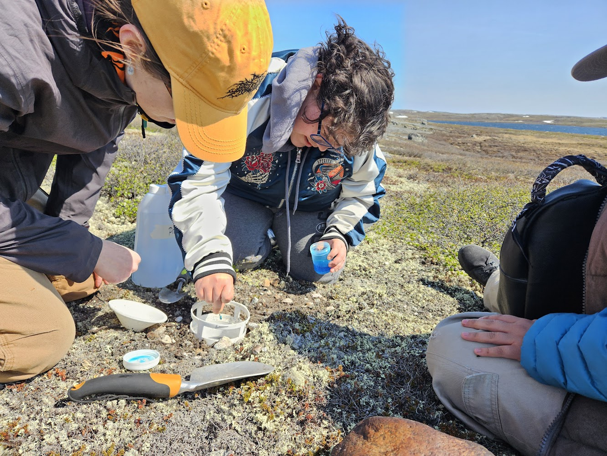

Installation of a pitfall trap in Inukjuak with Joëlle Spooner and Nunavik Sentinels Barbara Anautak and Alyster StCyr

© Caroline Dubé, MELCCFP.

## New spider species in Québec!

In the 2023 samples, we collected a total of 1971 spider specimens for a total of 84 spider species in Nunavik. For the whole province, 12 512 specimens were collected and identified in 2023, for a total of 206 species. This is only in one year! With the samples collected in 2023 with the help of the Uumajuit wardens, 5 species were sampled for the first time in Québec! These species can also be found in the Yukon, the West Coast, Nunavut, and for some, Greenland and Scandinavia.

Here are the new species for Québec:

New Spider Species to Québec in the 2023 Data

| Site | Species |
| --- | --- |
| Salluit | *Diplocephalus sphagnicola* |
| Salluit | *Emblyna borealis* |
| Salluit | One other species that remains unknown for now |
| Kangiqsualujjuaq | *Horcotes strandi* |
| Pingualuit | *Hilaira proletaria* |

## Amount of species of spiders by monitoring sites and latitude

In most groups of living organisms, species richness tends to decrease as we move toward the poles. For example, there are far more plant species in the Amazon rainforest than in the Arctic. But when it comes to spiders, things appear to be a bit different.

In the graph below, latitude is shown on the y-axis and the number of spider species on the x-axis. You’ll notice that in most sites across Nunavik, the number of spider species is not very different from what we see in southern Québec. The only noticeable decline in species richness starts around latitude 60°, which corresponds roughly to the regions of Kangirsuk and Puvirnituq. South of that, spider diversity appears to be just as high as it is farther south in the province. The diversity of spider species in Nunavik is truly impressive and highlights how unique and rich northern ecosystems can be!

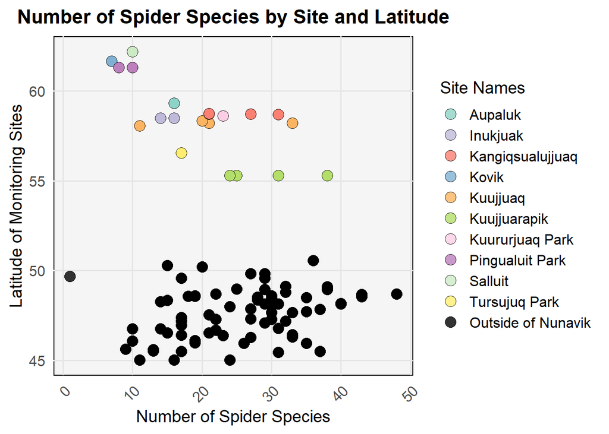

## Most detected spider species by monitoring site

In the graph below, you’ll find the species that were detected the most often in each monitoring area. The species that was detected the most often across all monitoring sites is *Pardosa uintana*, the Boreal thin-legged wolf spider. In a single monitoring year, the species was found over 120 times in the traps! Over all monitoring sites in Nunavik and all monitoring years, the species was collected 800 times.

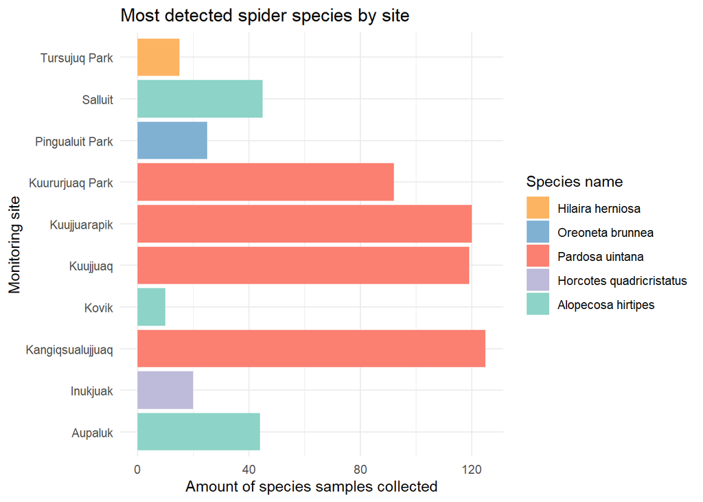

## Unique spider species by monitoring area

Here, we show how many unique species were found in each community and park. These species were not found elsewhere in Québec through the monitoring efforts of the Québec Biodiversity Monitoring Network. For outside of Nunavik, the average amount of unique species found by monitoring site is 1. Pingualuit Park is where unique species were most frequently detected. 9 species that have not been found anywhere else in Québec have been sampled out of two monitoring sites in the park.

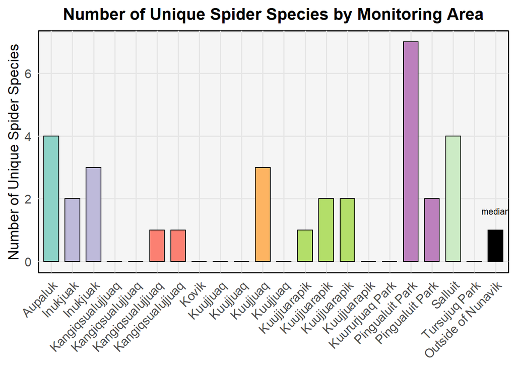

# What’s to come

As the project progresses, we plan to expand our monitoring efforts by visiting new sites across Nunavik, as well as revisiting those that were sampled 4 or 5 years ago to assess potential changes over time. The new data collected will enhance our analysis and provide deeper insights into the current state of Nunavik’s biodiversity. Your collaboration and contributions to the fieldwork make this project possible. Nakurmiik to everyone who helped out with this project on the land this year!

- Inukjuak
  - Alyster StCyr
  - Barbara Anautak
  - Johnny Mina
- Kangiqsualujjuaq
  - Elijah Etok
- Kuujjuaq
  - Alec Ningiuruvik
- Salluit
  - Putulik Cameron

Nakurmiik marialuk!